# HiPathia Bioconductor Package

Marta R. Hidalgo, Francisco Salavert, Çankut Cubuk, Alicia Amadoz, José Carbonell-Caballero, Joaquín Dopazo

2017-11-10

HiPathia is a method for the computation of signal transduction along signaling pathways. The method is based on an iterative algorithm which is able to compute the signal intensity passing through the nodes of a network by taking into account the level of expression of each gene and the intensity of the signal arriving to it.

## Introduction

HiPathia package implements the Canonical Circuit Activity Analysis method for the quantification of the signaling pathways activity presented in [Hidalgo et al.](https://www.ncbi.nlm.nih.gov/pubmed/28042959). It has been conceived as a functional tool for R users which allows more control on the analysis pipeline than the web implementation http://hipathia.babelomics.org.

This document will introduce you to the HiPathia package and how to use it to analyze your data.

## Previous considerations

### Example data

In order to illustrate the Hipathia package functionalities an example dataset has been prepared. Data has been downloaded from The Cancer Genome Atlas data repository, from the BRCA-US project. 20 tumor and 20 normal samples of RNA-Seq data have been randomly selected and normalized. Specifically, data has been corrected for batch effect using the COMBAT method, then corrected for RNA composition bias applying TMM normalization and log-transformed.

```r
library(hipathia)
data("brca_data")
```

The information about the type of these samples has been stored in a different dataset, and can be loaded in the same way as before.

```r
data("brca_design")
```

## Preprocessment

### Preprocess data

HiPathia accepts as input data a gene expression matrix. Expression may have been measured with any available sequencing technique. However, HiPathia assumes that data has been already normalized for correcting any possible sequencing bias (which includes also batch effect correction).

```r
hhead(brca_data)
```

```
##      TCGA.BH.A1FM.11B.23R.A13Q.07 TCGA.E2.A1LB.11A.22R.A144.07
## 2                      10.5317320                    9.7329379
## 8647                   -3.3266788                   -3.4575145
## 5244                   -0.3600828                   -1.1393086
## 1244                    2.2876961                    1.7246246
## 6833                   -0.1082559                    0.6923695
##      TCGA.BH.A208.11A.51R.A157.07 TCGA.BH.A18K.11A.13R.A12D.07
## 2                       9.7958036                    10.868669
## 8647                   -2.5261155                    -3.584934
## 5244                   -0.7368491                    -1.257797
## 1244                    1.0217356                     1.467979
## 6833                    0.2116428                     1.996456
##      TCGA.E9.A1RC.11A.33R.A157.07
## 2                      10.8883319
## 8647                   -0.1291559
## 5244                    0.7687009
## 1244                    2.1701113
## 6833                   -2.9271880
```

The gene expression matrix must include samples as columns and genes as rows, as shown in the previous example. Rownames must be the Entrez IDs of the genes in the rows. In order to transform other gene IDs to Entrez IDs, function `translate.matrix` can be used. Accepted IDs to be transformed to Entrez IDs include

**Human** * Affy HG U133A probeset * Affy HG U133B probeset * Affy HG U133-PLUS_2 probeset * Agilent SurePrint G3 GE 8x60k * Agilent SurePrint G3 GE 8x60k v2 * Agilent Whole Genome 4x44k * Agilent Whole Genome 4x44k v2 * CCDS * Ensembl gene * Ensembl transcript * Entrez ID * GenBank EMBL * GenBank PID * HGNC symbol * RefSeq mRNA * RefSeq mRNA PRED * RefSeq ncRNA * RefSeq ncRNA PRED

**Mouse** * Affy Mouse 430 2 * Ensembl gene * Gene name * Mouse Gene 1.0

**Rat** * Ensembl gene * Gene name

The parameters needed by this function are the data matrix and the species of the experiment.

```r
trans.data <- translate.matrix(brca_data, "hsa")
```

```
## [1] "Retrieving pathways data for hsa"
## translated ids = 3184 (1)
## untranslated ids = 3 (0.00094)
## multihit ids = 0 (0)
```

Apart from the necessary bias corrections, expression data must be normalized between 0 and 1 before applying the `hipathia` function. Function `normalize.data` is designed to this purpouse.

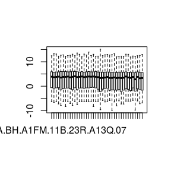

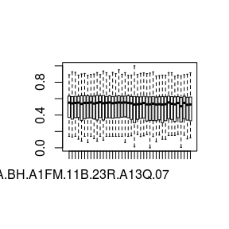

```r
boxplot(trans.data)
exp.data <- normalize.data(trans.data)
boxplot(exp.data)
```

Function `normalize.data` includes different parameters for normalization. If option `by.quantiles` is `TRUE`, a previous normalization by quantiles is performed.

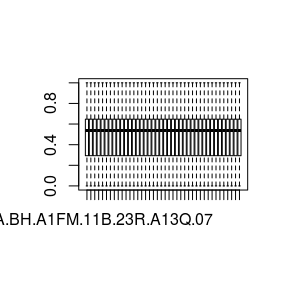

```r
exp.data <- normalize.data(trans.data, by.quantiles = TRUE)
boxplot(exp.data)
```

Other parameters of this function affect the way in which normalization to the interval [0,1] is performed. Parameter `by.gene` indicates whether to perform the transformation [0,1] to each row of the matrix. If the option `by.gene` is set to TRUE, the normalization between 0 and 1 is done for each row of the matrix, meaning that the expression of each gene will have a range between 0 and 1. If it is set to FALSE, the normalization is done for the whole matrix, meaning that only the genes with the maximum value of the matrix will have a normalized value of 1. It is recommended to keep it set to `FALSE`, as the default value.

Parameter `percentil` indicates whether to use the percentil to compute the normalized value between 0 and 1. If it is set to TRUE, the function takes as a value for the position `(i,j)` of the matrix the percentil of sample `j` in the ditribution of gene `i`. If it is seet to FALSE, the functions applies a direct transformation from the original interval to [0,1]. It is recommended to keep it set to `FALSE` except for heavy-tailed distributions of the genes.

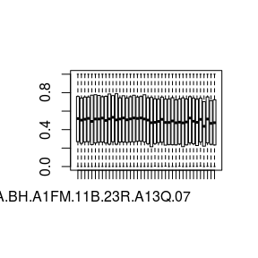

```r
exp.data <- normalize.data(trans.data, percentil = TRUE)
boxplot(exp.data)
```

Parameter `truncation.percentil` gives the value of percentil `p` from which all further values are truncated to percentil `p`. Symmetrically, values beyond percentil `1-p` are also truncated to `1-p`.

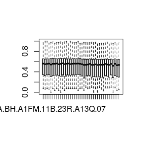

```r
exp.data <- normalize.data(trans.data, truncation.percentil = 0.95)
boxplot(exp.data)
```

### Load pathways

Hipathia package is currently implemented to use preprocessed KEGG pathways. The pathways have been processed and stored in a pathways object. This object includes all the information that the different functions in the package need. In order to load this object, use function `load.pathways` and select the species to be analyzed. Available species include human (“hsa”), mouse (“mmu”) and rat (“rno”).

```r
pathways <- load.pathways(species = "hsa")
```

```
## [1] "Retrieving pathways data for hsa"
## Loaded 145 pathways
```

Parameter `pathways.list` allows the user to specify the pathways to be loaded. The different functions of the package will use all the pathways in the pathways object for its computations. In order to restrict the analysis to a particular set of pathways, load only the required pathways to the pathway object. By default, all pathways available for the specified species are loaded.

```r
pathways2 <- load.pathways(species = "hsa", pathways.list = c("hsa03320", "hsa04014"))
```

```
## [1] "Retrieving pathways data for hsa"
## Loaded 2 pathways
```

In order to know which pathways are included in each pathways object, function `get.pathways.list` can be used.

```r
length(get.pathways.list(pathways))
```

```
## [1] 145
```

```r
get.pathways.list(pathways)
```

```
##   [1] "hsa03320" "hsa03460" "hsa04010" "hsa04012" "hsa04014" "hsa04015"
##   [7] "hsa04020" "hsa04022" "hsa04024" "hsa04062" "hsa04064" "hsa04066"
##  [13] "hsa04068" "hsa04071" "hsa04072" "hsa04110" "hsa04114" "hsa04115"
##  [19] "hsa04150" "hsa04151" "hsa04152" "hsa04210" "hsa04211" "hsa04213"
##  [25] "hsa04261" "hsa04270" "hsa04310" "hsa04330" "hsa04340" "hsa04350"
##  [31] "hsa04360" "hsa04370" "hsa04380" "hsa04390" "hsa04510" "hsa04520"
##  [37] "hsa04530" "hsa04540" "hsa04550" "hsa04610" "hsa04611" "hsa04612"
##  [43] "hsa04620" "hsa04621" "hsa04622" "hsa04623" "hsa04630" "hsa04650"
##  [49] "hsa04660" "hsa04662" "hsa04664" "hsa04666" "hsa04668" "hsa04670"
##  [55] "hsa04710" "hsa04713" "hsa04720" "hsa04722" "hsa04723" "hsa04724"
##  [61] "hsa04725" "hsa04726" "hsa04727" "hsa04728" "hsa04730" "hsa04740"
##  [67] "hsa04742" "hsa04750" "hsa04810" "hsa04910" "hsa04911" "hsa04912"
##  [73] "hsa04913" "hsa04914" "hsa04915" "hsa04916" "hsa04917" "hsa04918"
##  [79] "hsa04919" "hsa04920" "hsa04921" "hsa04922" "hsa04923" "hsa04924"
##  [85] "hsa04925" "hsa04930" "hsa04931" "hsa04932" "hsa04933" "hsa04950"
##  [91] "hsa04960" "hsa04961" "hsa04962" "hsa04970" "hsa04971" "hsa04972"
##  [97] "hsa04973" "hsa04976" "hsa05010" "hsa05012" "hsa05014" "hsa05016"
## [103] "hsa05020" "hsa05030" "hsa05031" "hsa05032" "hsa05034" "hsa05100"
## [109] "hsa05110" "hsa05120" "hsa05130" "hsa05131" "hsa05132" "hsa05133"
## [115] "hsa05134" "hsa05140" "hsa05142" "hsa05145" "hsa05150" "hsa05152"
## [121] "hsa05160" "hsa05161" "hsa05162" "hsa05164" "hsa05166" "hsa05168"
## [127] "hsa05169" "hsa05200" "hsa05205" "hsa05210" "hsa05211" "hsa05212"
## [133] "hsa05213" "hsa05214" "hsa05215" "hsa05216" "hsa05217" "hsa05218"
## [139] "hsa05219" "hsa05220" "hsa05221" "hsa05222" "hsa05223" "hsa05231"
## [145] "hsa05321"
```

```r
length(get.pathways.list(pathways2))
```

```
## [1] 2
```

```r
get.pathways.list(pathways2)
```

```
## [1] "hsa03320" "hsa04014"
```

## Pathway activation computation

HiPathia aims to compute the level of activation of each subpathway in a pathway for each of the samples from the experiment. This is done by function `hipathia`, which takes as inputs the matrix of gene expression, the pathways object and some other parameters.

Parameter `decompose` indicates whether to use effector subpathways or to decompose the pathways into decomposed subpathways. For further information on this, see next section **Subpathways**. For further information on the method used to compute the level of signal activity in the pathways, see Section **Computing the signal** or refer to [Hidalgo et al.](https://www.ncbi.nlm.nih.gov/pubmed/28042959).

```r
results <- hipathia(exp.data, pathways, decompose = FALSE, verbose=FALSE)
```

```
## Added missing genes: 144 (4.33%)
```

The resulting object includes the level of activity of the signal in each subpathway as well as further information of the computation. In order to extract the matrix of signal activity values from this object use function `get.paths.matrix`.

```r
path.vals <- get.paths.matrix(results)
hhead(path.vals)
```

```
##               TCGA.BH.A1FM.11B.23R.A13Q.07 TCGA.E2.A1LB.11A.22R.A144.07
## P-hsa03320-37                   0.42896593                   0.37775624
## P-hsa03320-61                   0.19398922                   0.19805778
## P-hsa03320-46                   0.09120405                   0.08985045
## P-hsa03320-57                   0.10329939                   0.10176627
## P-hsa03320-64                   0.08858846                   0.12283124
##               TCGA.BH.A208.11A.51R.A157.07 TCGA.BH.A18K.11A.13R.A12D.07
## P-hsa03320-37                    0.4024025                   0.41396505
## P-hsa03320-61                    0.1655702                   0.18774026
## P-hsa03320-46                    0.0905164                   0.09280719
## P-hsa03320-57                    0.1025205                   0.13953972
## P-hsa03320-64                    0.1247137                   0.11942845
##               TCGA.E9.A1RC.11A.33R.A157.07
## P-hsa03320-37                   0.15318680
## P-hsa03320-61                   0.21256025
## P-hsa03320-46                   0.09518472
## P-hsa03320-57                   0.10780797
## P-hsa03320-64                   0.09245496
```

Rownames of the matrix of pathway results are the IDs of the subpathways. In order to transform this ID to a comprehensive name, use `get.path.names` function. However, it is not recommended to change the row names of this matrix.

```r
path.names <- get.path.names(pathways, rownames(path.vals))
head(path.names)
```

```
## [1] "PPAR signaling pathway: HMGCS2" "PPAR signaling pathway: APOA1"
## [3] "PPAR signaling pathway: APOA2"  "PPAR signaling pathway: APOC3"
## [5] "PPAR signaling pathway: APOA5"  "PPAR signaling pathway: PLTP"
```

Notice that the matrix of subpathway activity values will include a value of activity for each sample and for each possible subpathway of the pathways in the pathway object. Depending on whether parameter `decompose` is set to TRUE or FALSE, and on the number of pathways included in the object of pathways given as attribute, the number of analyzed subpathways may vary. Currently HiPathia includes up to the following number of pathways, effector subpathways and decomposed subpathways per species:

[output not shown]

### Subpathways

Pathways are represented by directed graphs, which include different input and output nodes. The signal arrives to an initial node and is transmited along the pathway following the direction of the interactions up to an output node. Thus, the signal may follow many different paths along the pathway. HiPathia computes the intensity of this signal up to each output node of a pathway separately.

Genes in the output nodes are also called *effector proteins*, since they are the ones responsibles for performing the action the signal is seeking. We define the *effector subpathway* ending in node *G* as the subgraph including any node in a path leading to *G*. When applied to effector subpathways, HiPathia returns the intensity of the signal arriving to the effector protein *G*.

Effector subpathways may have many different input nodes. In order to analyze in detail which of the possible paths leading to node *G* is responsible for the observed change, effector subpathays can be decomposed into several subpathways including only one input node. We define the *decomposed subpathway* from *H* to *G* as the subgraph including any node in a path from *H* to *G*.

It is recommended to perform an initial HiPathia analysis with effector subpathways, and use decomposed subpathways only for specific pathways in which the user is highly interested.

### Computing the signal

In order for a protein to pass the signal, there are two important factors: first, the protein must be present, and second, some other protein must activate it. Therefore, HiPathia is a method to compute signal transduction based on two steps. First, it quantifies the presence of a particular gene as a normalized value between 0 and 1. Then, it computes the signal value passing through a node taking into account the level of expression of each gene inside the node and the intensity of the signal arriving to it. The signal value of the pathway is the signal value through the last node of the pathway.

#### Node expression

Pathways are representaed by graphs and composed by nodes and relations among them. Some nodes may contain multiple genes representing different isoforms of the protein or members of the same gene familiy, among others. Since each gene has its own level of expression, the first step of the method is to summarize this information into a score representing the expression of the node as a whole.

#### Signal transduction

The computation of the signal intensity across the pathway is performed by means of an iterative algorithm beginning in the input nodes of the subpathway. In order to initialize the pathway signal we assume an incoming signal value of 1 in the input nodes of the subpathway. Then, for each node $n$ of the network, the signal value is propagated along the nodes according to the following rule
$$\begin{equation}
\label{formula}
S_n = v\cdot(1-\prod_{s_i \in A}(1-s_i))\cdot\prod_{s_j\in I}(1-s_j)
\end{equation}$$

where $A$ is the set of signals arriving to the node from an activation edge, $I$ is the set of signals arriving to the node from an inhibition edge, and $v$ is the normalized value of the current node.

## Function activation computation

Each effector protein of a pathway is responsible for performing a particular function. Thus, from the matrix of effector subpathways we can infer the functions matrix, which gives an intensity value for each molecular function and for each sample.

Different effector subpathways of different pathways may end in the same effector protein, and also different effector genes may have the same molecular function. Therefore, for a particular function $f$, we summarize the values of all the subpathways ending in an effector protein related to $f$ with a mean value.

Different function activity matrices can be computed depending on the functional annotation given to the effector nodes. Function `quantify.terms` accepts any annotation defined by the user and it has also two default annotations: Gene Ontology functions and Uniprot keywords.

```r
uniprot.vals <- quantify.terms(results, pathways, "uniprot")
```

```
## [1] "Retrieving pathways data for hsa"
## Quantified functions: 142
```

```r
go.vals <- quantify.terms(results, pathways, "GO")
```

```
## [1] "Retrieving pathways data for hsa"
## Quantified functions: 1654
```

The result of this function is a matrix with the level of activity of each annotated function for each sample. Notice that functions annotated to genes which are not included in any effector node will be not computed.

## Pathway/Function activation analysis

Once the matrix of desired features has been computed, any kind of analysis may be performed on it, in the same way as if it were the matrix of gene expressions. Specifically, comparison of the features across different groups of samples is one of the keys. We can perform a comparison of two groups applying the Wilcoxon test using function `do.wilcoxon`.

```r
sample.group <- brca_design[colnames(path.vals),"group"]
comp <- do.wilcoxon(path.vals, sample.group, g1 = "Tumor", g2 = "Normal")
hhead(comp)
```

```
##                   p.value UP/DOWN  statistic FDRp.value
## P-hsa03320-37 0.024467723    DOWN -2.2451574 0.04654349
## P-hsa03320-61 0.383413282    DOWN -0.8926529 0.46628647
## P-hsa03320-46 0.010314038    DOWN -2.5427084 0.02155103
## P-hsa03320-57 0.009483607    DOWN -2.5697585 0.02010826
## P-hsa03320-64 0.758350956    DOWN -0.3246011 0.81227041
```

Function `get.pathways.summary` returns a summary by pathway of the results from the Wilcoxon test, summaryzing the number of significant up- or down-activated features.

```r
pathways.summary <- get.pathways.summary(comp, pathways)
head(pathways.summary, n = 15)
```

```
##                                                          id.pathways
## Notch signaling pathway                                     hsa04330
## Signaling pathways regulating pluripotency of stem cells    hsa04550
## Fc epsilon RI signaling pathway                             hsa04664
## Circadian rhythm                                            hsa04710
## Long-term depression                                        hsa04730
## Insulin secretion                                           hsa04911
## Vasopressin-regulated water reabsorption                    hsa04962
## Parkinson's disease                                         hsa05012
## cGMP-PKG signaling pathway                                  hsa04022
## Neurotrophin signaling pathway                              hsa04722
## Jak-STAT signaling pathway                                  hsa04630
## Retrograde endocannabinoid signaling                        hsa04723
## Oxytocin signaling pathway                                  hsa04921
## Prion diseases                                              hsa05020
## Regulation of lipolysis in adipocytes                       hsa04923
##                                                          num.total.paths
## Notch signaling pathway                                                3
## Signaling pathways regulating pluripotency of stem cells              14
## Fc epsilon RI signaling pathway                                        6
## Circadian rhythm                                                       4
## Long-term depression                                                   4
## Insulin secretion                                                      8
## Vasopressin-regulated water reabsorption                               2
## Parkinson's disease                                                    3
## cGMP-PKG signaling pathway                                            22
## Neurotrophin signaling pathway                                        12
## Jak-STAT signaling pathway                                            11
## Retrograde endocannabinoid signaling                                  11
## Oxytocin signaling pathway                                            22
## Prion diseases                                                        10
## Regulation of lipolysis in adipocytes                                  7
##                                                          num.significant.paths
## Notch signaling pathway                                                      3
## Signaling pathways regulating pluripotency of stem cells                    14
## Fc epsilon RI signaling pathway                                              6
## Circadian rhythm                                                             4
## Long-term depression                                                         4
## Insulin secretion                                                            8
## Vasopressin-regulated water reabsorption                                     2
```

[output cut: 73 more lines]

```
## Notch signaling pathway                                               66.67
## Signaling pathways regulating pluripotency of stem cells              85.71
## Fc epsilon RI signaling pathway                                      100.00
## Circadian rhythm                                                      50.00
## Long-term depression                                                 100.00
## Insulin secretion                                                     75.00
## Vasopressin-regulated water reabsorption                             100.00
## Parkinson's disease                                                   66.67
## cGMP-PKG signaling pathway                                            81.82
## Neurotrophin signaling pathway                                        66.67
## Jak-STAT signaling pathway                                            18.18
## Retrograde endocannabinoid signaling                                  54.55
## Oxytocin signaling pathway                                            77.27
## Prion diseases                                                        80.00
## Regulation of lipolysis in adipocytes                                 71.43
```

Principal Components Analysis can be also performed by using function `do.pca`. Notice that the number of rows must not exceed the number of columns of the input matrix.

```r
ranked.path.vals <- path.vals[order(comp$p.value, decreasing = FALSE),]
pca.model <- do.pca(ranked.path.vals[1:ncol(ranked.path.vals),])
```

PCA models can be visualized with a specific function called `pca.plot`. See section **Visualization** for further information.

## Visualization

### Heatmap

Function `heatmap.plot` plots a heatmap with the values of the given matrix. The experimental design can be provided to assign a class to each sample by means of the parameter `sample.type`. Notice that the calsses must be in the same order as the columns of the provided matrix. One can select whether to cluster samples or variables with parameters `variable.clust` and `sample.clust`. The colors of the different classes of samples can be selected through parameter `sample.colors` with a vector of colors named after the classes. The colors inside the heatmap can be also selected with parameter `colors`. Personalized colors can be provided as a vector, or preselected color schemes *classic* (default), *hipathia* or *redgreen* may be chosen.

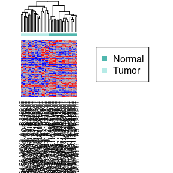

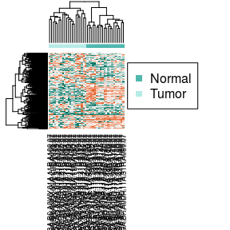

```r
heatmap.plot(path.vals, sample.type=sample.group)
heatmap.plot(path.vals, sample.type=sample.group, colors="hipathia", variable.clust = TRUE)
```

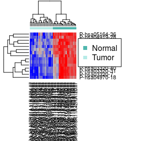

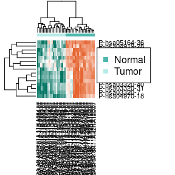

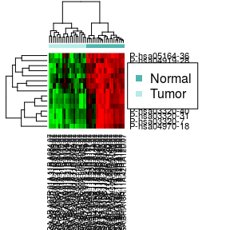

```r
heatmap.plot(ranked.path.vals[1:15,], sample.type=sample.group, variable.clust = TRUE)
heatmap.plot(ranked.path.vals[1:15,], sample.group, colors="hipathia", variable.clust = TRUE)
heatmap.plot(ranked.path.vals[1:15,], sample.group, colors="redgreen", variable.clust = TRUE)
```

### PCA

Function `pca.plot` plots two components of a PCA model computed with function `do.pca` (see section **Pathway/Function activation analysis**). The experimental design can be provided to assign a class to each sample by means of the parameter `sample.type`. Notice that the classes must be in the same order as the columns of the matrix provided to the PCA model. The colors of the different classes of samples can be selected through parameter `sample.colors` with a vector of colors named after the classes. If no such parameter is provided, a predefined set of colors will be assigned. A main title may be given to the plot through parameter `main`. The components to be plotted can be selected through parameters `cp1` and `cp2` giving integer number. If parameter `legend` is set to TRUE, the legend will be plotted.

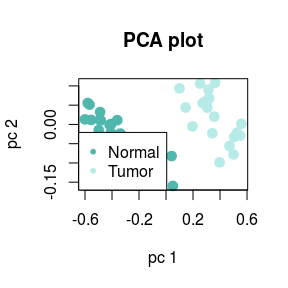

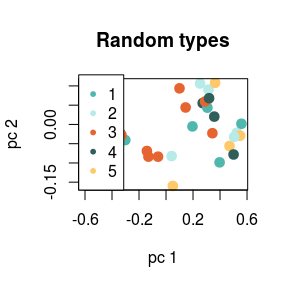

```r
pca.plot(pca.model, sample.group, legend = TRUE)
pca.plot(pca.model, sample.type = rep(1:5, 8), main = "Random types", legend = TRUE)
```

Function `multiple.pca.plot` plots $n$ PCA components given by parameter `comps` as an integer vector. As before, the experimental design can be provided to assign a class to each sample by means of the parameter `sample.type`. Notice that the classes must be in the same order as the columns of the matrix provided to the PCA model. The colors of the different classes of samples can be selected through parameter `sample.colors` with a vector of colors named after the classes. If no such parameter is provided, a predefined set of colors will be assigned. The cumulative explained variance can be represented by setting `plot.variance` parameter to TRUE. If parameter `legend` is set to TRUE, the legend will be plotted. A main title may be given to the plot through parameter `main`.

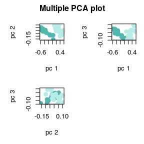

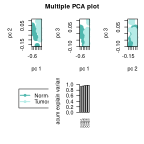

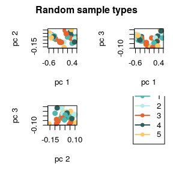

```r
multiple.pca.plot(pca.model, sample.group, plot.variance = FALSE, legend = FALSE)
multiple.pca.plot(pca.model, sample.group, cex=3, plot.variance = TRUE)
multiple.pca.plot(pca.model, sample.type = rep(1:5, 8), main = "Random sample types")
```

### Pathway comparison

The results of a comparison are sometimes difficult to summarize. An easy way to understand these results is to visualize them as an image. Function `pathway.comparison.plot` creates an image of a pathway, with the same layout from KEGG, including a color code representing the significant up- and down-activated subpathways, and, if desired, the significant up- and down-regulated nodes.

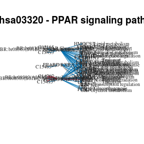

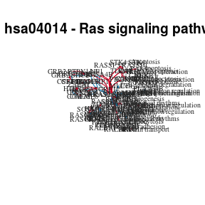

```r
pathway.comparison.plot(comp, metaginfo = pathways, pathway = "hsa03320")
pathway.comparison.plot(comp, metaginfo = pathways, pathway = "hsa04014")
```

In these plots, colored edges represent significant subpathways. Edges belonging to subpathways which are significantly down-activated will be depicted in blue and those belonging to subpathways which are significantly up-activated will be depicted in red (as default). The *up* and *down* colors may be changed by the user through the parameter `colors` by giving a vector with three colors (representing down-activation, non-significance and up-activation respectively) or a color scheme (either *classic* or *hipathia*).

In order to visualize the effect of the nodes expression differences in the pathways, nodes can be colored by its differential expression. The color of each node with respect to its differential expression must be previously computed using function `node.color.per.differential.expression`. Note that this fucntion computes differential expression on the nodes, not on the genes. It uses function `eBayes` from package `limma`, see the `limma` package vignette for further information.

When computed, the resulting object must be provided to the `pathway.comparison.plot` function as parameter `node.colors`.

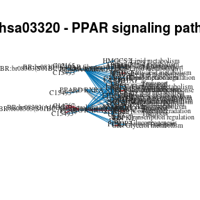

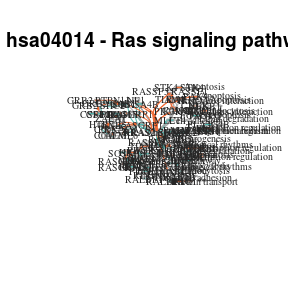

```r
colors.de <- node.color.per.differential.expression(results, pathways, sample.group, "Tumor", "Normal")
pathway.comparison.plot(comp, metaginfo = pathways, pathway = "hsa03320", node.colors = colors.de)
colors.de.hipathia <- node.color.per.differential.expression(results, pathways, sample.group, "Tumor", "Normal", colors = "hipathia")
pathway.comparison.plot(comp, metaginfo = pathways, pathway = "hsa04014", node.colors = colors.de.hipathia, colors = "hipathia")
```

### Visualization through a local server

```r
create.report(results, comp, pathways, "save_noColors")
create.report(results, comp, pathways, "save_colors", node.colors = colors.de)
```

Due to cross-origin security restrictions ([CORS](https://en.wikipedia.org/wiki/Cross-origin_resource_sharing)), a web server is needed to serve the result files correctly. The easiest way to run a web server to show the result files is with the Hipathia function `visualize.report`. The user must specify the folder where the report has been stored by function `create.report`. A web server developed in R will be executed, serving the result files to the default URL http://127.0.0.1:4000. Port 4000 may be changed through parameter `port`.

```r
visualize.report("save_colors")
```

```
## Open a web browser and go to URL http://127.0.0.1:4000
```

```
## Serving the directory /home/mhidalgo/appl/hipathia_package/vignettes/save_colors/pathway-viewer at http://127.0.0.1:4000
```

```r
visualize.report("save_noColors", port = 4001)
```

```
## Open a web browser and go to URL http://127.0.0.1:4001
```

```
## Serving the directory /home/mhidalgo/appl/hipathia_package/vignettes/save_noColors/pathway-viewer at http://127.0.0.1:4001
```

The function `visualize.report` uses the `servr` package, please refer to servr for further information.

```r
servr::daemon_stop()
```

Alternatively, if you have already a web server installed in your computer, just link or move the output folder to your web server http document root and then open it on your web browser.

#### Interpreting HTML results

The interactive visualization of HiPathia results includes three panels and a legend. The legend is on top of the page resuming the main information depicted in the images. The left panel is the pathways panel, where the currently selected pathway is shown. The layout of the pathway is similar to the layout shown in KEGG.

As before, edges belonging to significant down-activated pathways are depicted in blue, those belonging to significant up-activated subpathways are depicted in red, and those belonging to non-significant subpathways are depicted in grey. Similarly, when nodes are colored by their differential expression, down-regulated nodes are colored in blue, up-regulated nodes are colored in red and non-significant nodes are colored in white. Different shades of the colors indicate different levels of significance with respect to the p-value of the differential expression.

The selected pathway to be shown can be modified through the pathway list in the top right panel. Arrows pointing up and down lo the left of the names of the pathways indicates that the pathways contain up- or down-activated subpathways, respectively. When the arrows are colored in red or blue, it means that there are significant up- or down-regulated subpathways, respectively. The pathways list can be filtered through the *Filter…* box, or ordered by means of the buttons in the top right part of the panel.

All computed subpathways of the currently selected pathway are listed in the subpathways list in the bottom right panel. Arrows pointing up and down by the names of the subpathways indicates that they are up- or down-activated, respectively. When the arrows are colored in red or blue, it means that they are significantly up- or down-regulated, respectively. When a subpathway is selected from the list, only the arrows and nodes belonging to this subpathway will be highlighted. Clicking again on this subpathway will deselect it.